# Assignment 2

## Continuous Cartogram Sized by Percentage of Population that is African American

Here I am still color coding the states by Eviction Rate but I am distorting the shapes of the states by the percentage of the population that is African American. I was predicting that these two variables would be telling when paired, but this cartogram is pretty illegible. It does look like the “larger” states in the South and South East with a high percentage of African Americans have medium to high eviction rates.

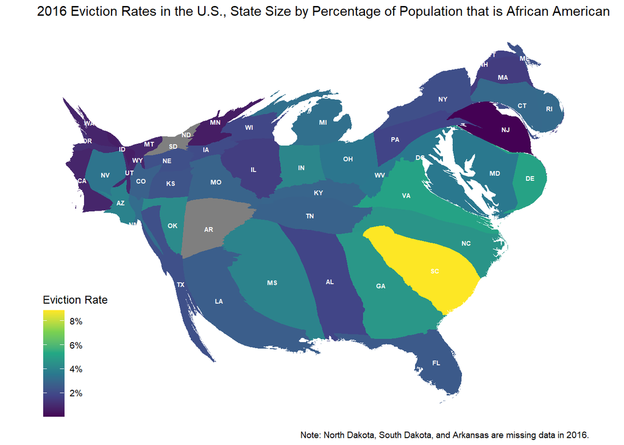

```r
evictions_cartogram_cont <- evictions_states %>%
  cartogram_cont("pct-af-am")

ggplot(evictions_cartogram_cont, aes(fill = `eviction-rate`)) +
  geom_sf(color = NA) +
    labs(title = "2016 Eviction Rates in the U.S., State Size by Percentage of Population that is African American") +
  labs(caption = "Note: North Dakota, South Dakota, and Arkansas are missing data in 2016.") +
  scale_fill_viridis_c(name = "Eviction Rate", breaks = seq(0,10, by = 2), labels = c("0%", "2%", "4%", "6%", "8%", "10%")) +
  geom_sf_label(aes(geometry, label = postal), size = 1.8, color = "white", fill = NA, label.size = NA, fontface = "bold",) +
  theme_map() +
  theme(legend.background = element_blank())
```

## Dorling Cartogram

Here is a Dorling Cartogram, again referencing total population size, where I’ve labeled each state’s bubble with it’s eviction rate for further clarity.

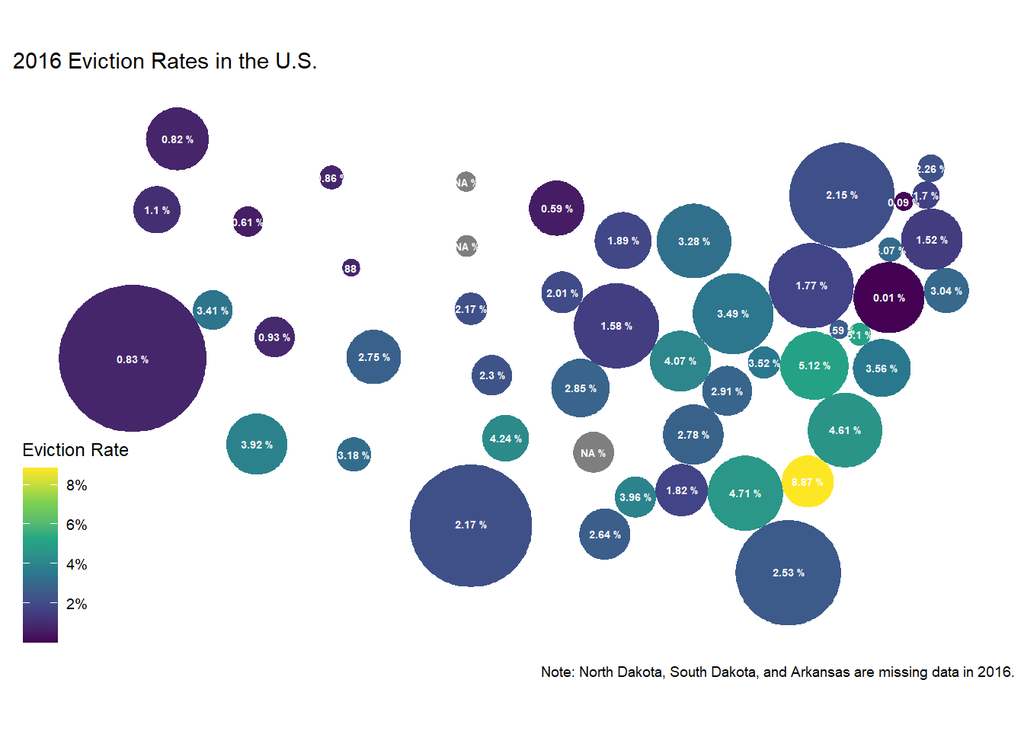

```r
evictions_cartogram_dorling <- evictions_states %>%
  cartogram_dorling("population")

ggplot(evictions_cartogram_dorling, aes(fill = `eviction-rate`)) +
  geom_sf(color = NA) +
  labs(title = "2016 Eviction Rates in the U.S.") +
  labs(caption = "Note: North Dakota, South Dakota, and Arkansas are missing data in 2016.") +
  scale_fill_viridis_c(name = "Eviction Rate", breaks = seq(0,10, by = 2), labels = c("0%", "2%", "4%", "6%", "8%", "10%")) +
    geom_sf_label(aes(geometry, label = paste(`eviction-rate`, "%")), size = 1.9, color = "white", fill = NA, label.size = NA, fontface = "bold",) +
  theme_map() +
  theme(legend.background = element_blank())
```

## Proportional Symbol Map

Here is a proportional dot map. It looks like there are high eviction rates along the east coast, especially in the South East, but the representation could be misleading because those states are also small and close together.

```r
evictions_centeroids <- evictions_states %>%
  st_centroid()
```

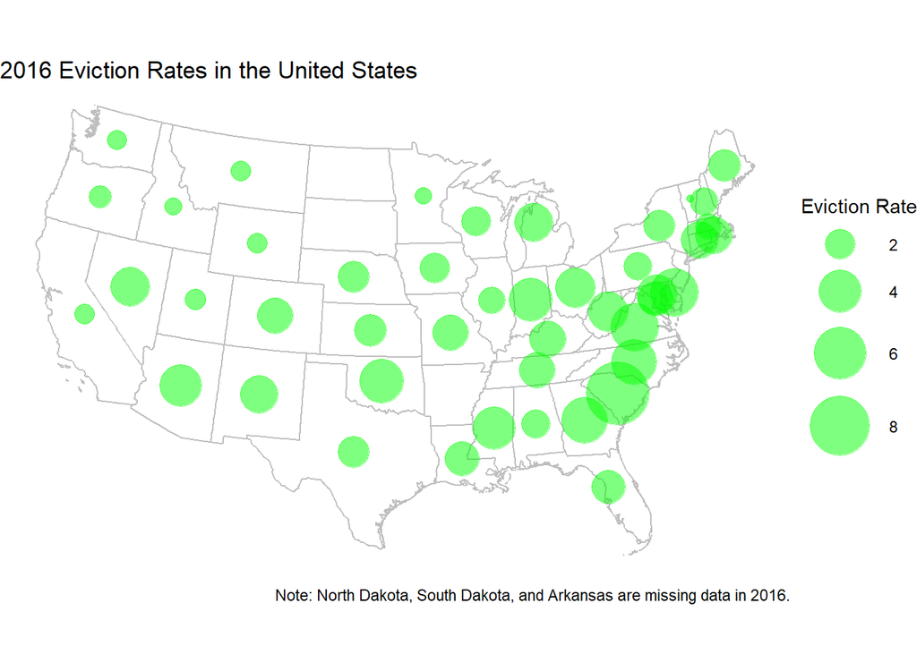

```r
ggplot(states_transformed) +
  geom_sf(fill = NA, color = "gray") +
  labs(title = "2016 Eviction Rates in the United States") +
  labs(caption = "Note: North Dakota, South Dakota, and Arkansas are missing data in 2016.") +
  geom_sf(data = evictions_centeroids,
          aes(size = `eviction-rate`),
          alpha = 0.5, color = "green") +
  scale_size_continuous(name = "Eviction Rate", range = c(0, 16)) +
  theme_void()
```